# Divvy, Casual vs Annual Users

Ian Campbell

2024-10-18

Our project lead has concluded that converting casual bike riders to annual members will increase revenue. In order to facilitate this conversion, we are analyzing how the two categories differ, allowing us to better target casual riders.

Our data is a history of rides over the last 12 months, including, duration, location, rider subscription type and more. The data is reliable as it comes from within the company, it is original, comprehensive, and current. From this data we should be able to differentiate behaviors of casual and annual bike riders.

Ride information is anonymized.

## Asking Questions

To gain an understanding of the bikeshare industry, I relied on chatGPT for guidance. I asked questions like, “What should I know about bikeshares as a data analyst?” And found that

- seasonality,
- time of day,
- time of week,
- distance and
- duration

were all factors worth considering in an analysis. These factors could be analyzed given the Divvy dataset.

## Data Cleaning

Analysis and cleaning was done in R. A list of data cleaning steps follows.

- Started_at and ended_at columns are parsed as strings; converted them to date type.
- No duplicate rows found.
- There are more station names than station ids, indicating that some stations may have multiple names, or there are misspelled station names.
- Apparently, many rides do not have an end and/or start station. I’m assuming that this is normal since so many records have this feature.
- Some rides lack end_lat and end_long: these have been omitted.
- Other rides have a negative duration: these have also been omitted.

## Analysis

Rider behavior differed by month, day of the week, and time of day, in the number of rides taken and duration of each ride. It appears that annual riders are using the service for commuting and work, whereas casual riders are more exploratory.

### General

Members take less time on rides than casual riders.

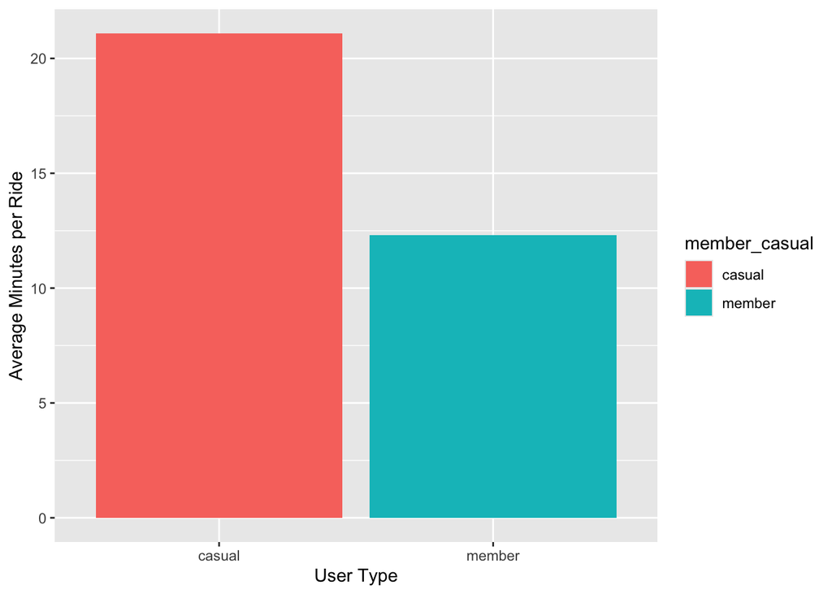

Members take more rides than casual users.

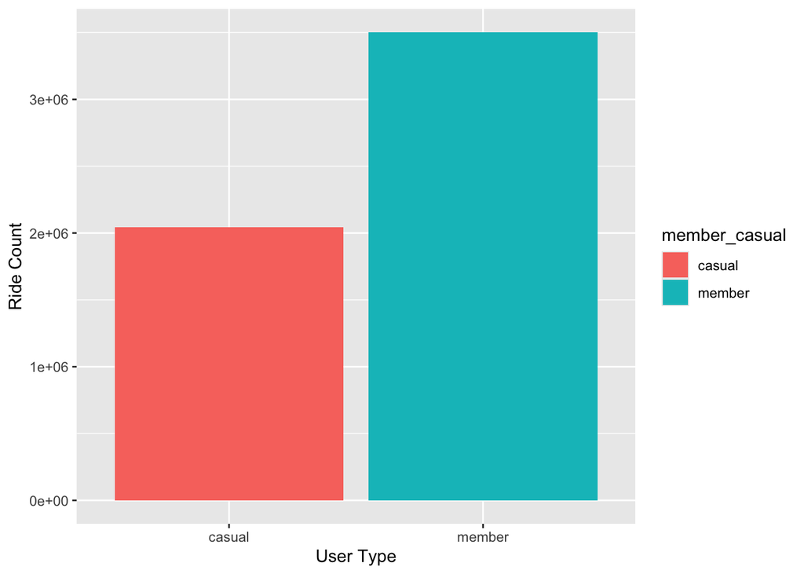

Members take more rides yet spend less time on average per ride than casual users. This could be because they go shorter distances. We don’t have data on the actual path that users take, but we can estimate distance traveled by getting the distance as the crow flies between start and stop points.

This is about the same for both users, which means that annual users are efficient; they get from point A to B more quickly than casual users. This may be because they know their destination, just like a commuter would, whereas casual users may dally about or make more mistakes travelling. It may also be because members are more athletic.

Based on this, I assume that longer rides over the same distance means more exploratory and enjoyable behavior.

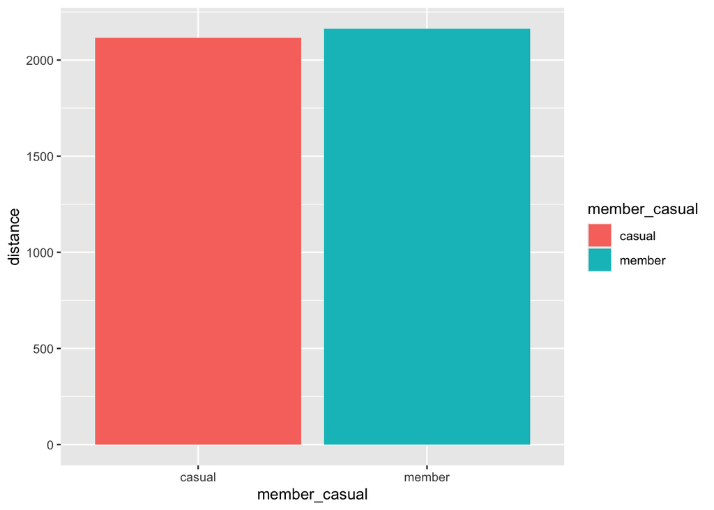

### Monthly Breakdown

A monthly breakdown of average time per ride reveals less variation over season for members than for casual users.

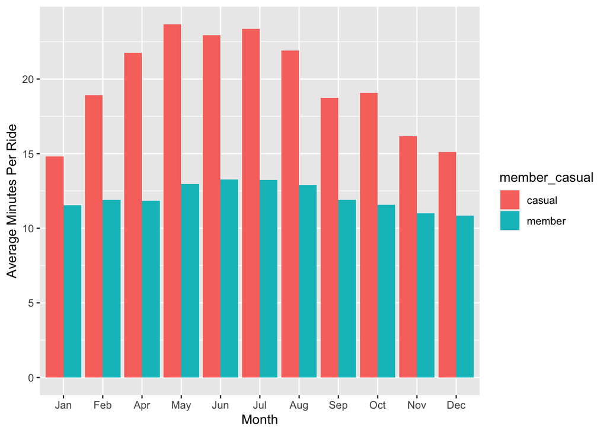

However, Rides Taken shows the same seasonal pattern for both types of bikers. This indicates that members are doing more of the same types of trips during the summer, while casual users are more exploratory during the summer and less so during the winter.

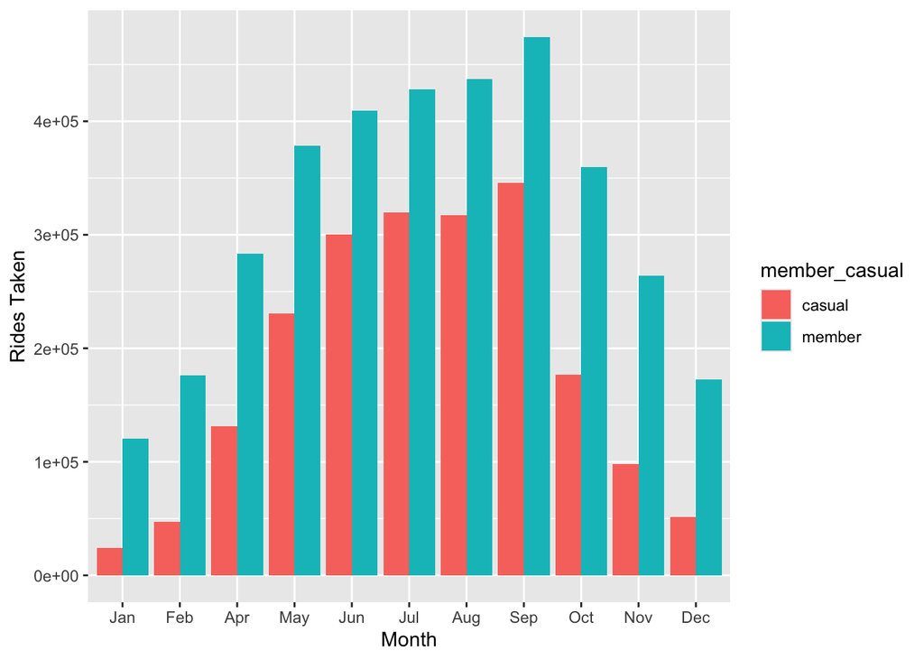

### Weekly Breakdown

Looking at usage over the week, we see that time per ride is greater over the weekend for casual riders, with the trend being almost nonexistent for members. This could indicate that casual rides over the weekdays are more often utilitarian, while member riders are more utilitarian across the board.

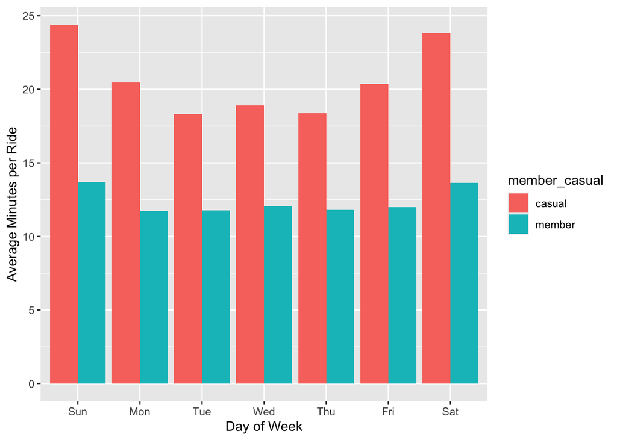

However, when we look at rides taken, member rides peak during the weekdays, while casual riders peak during the weekends. This observation might mean that members are using Divvy to get to and from work, while casual riders are, again, using it for pleasure.

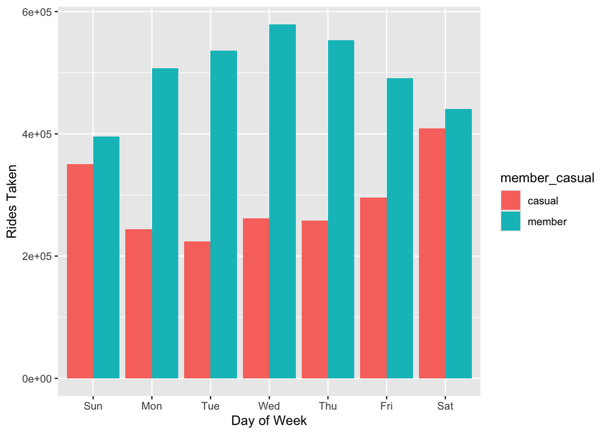

### Hourly Breakdown

More evidence that members are using the bikeshare program to commute comes from the hourly distribution of rides taken. Member rides spike at 800 (8am) and again at 1700 (5pm). These are commute times. Casual rides peak only at 5pm.

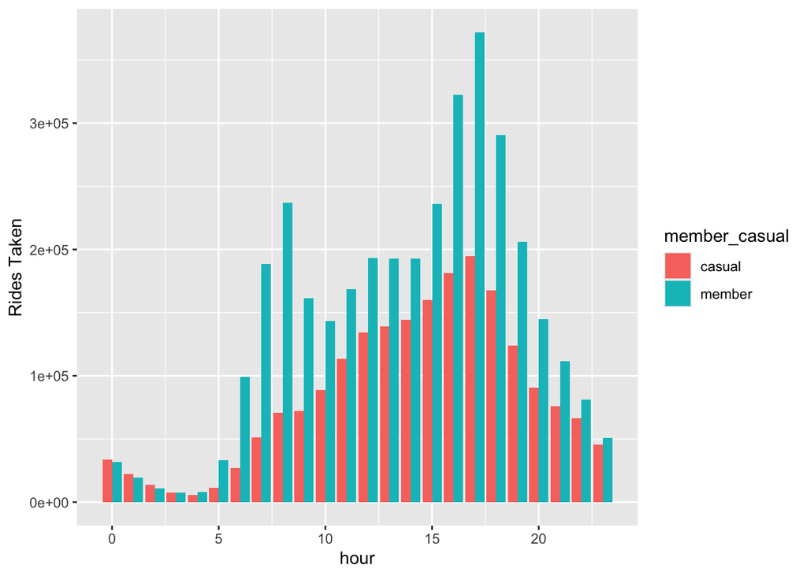

Casual riders vary over the day in their minutes per ride, with the longest, 25 minute rides happening at 10am. Members are largely consistent, taking 12 minutes a ride on average regardless of time of day. This is consistent with the exploratory/utilitarian split between casual and member riders.

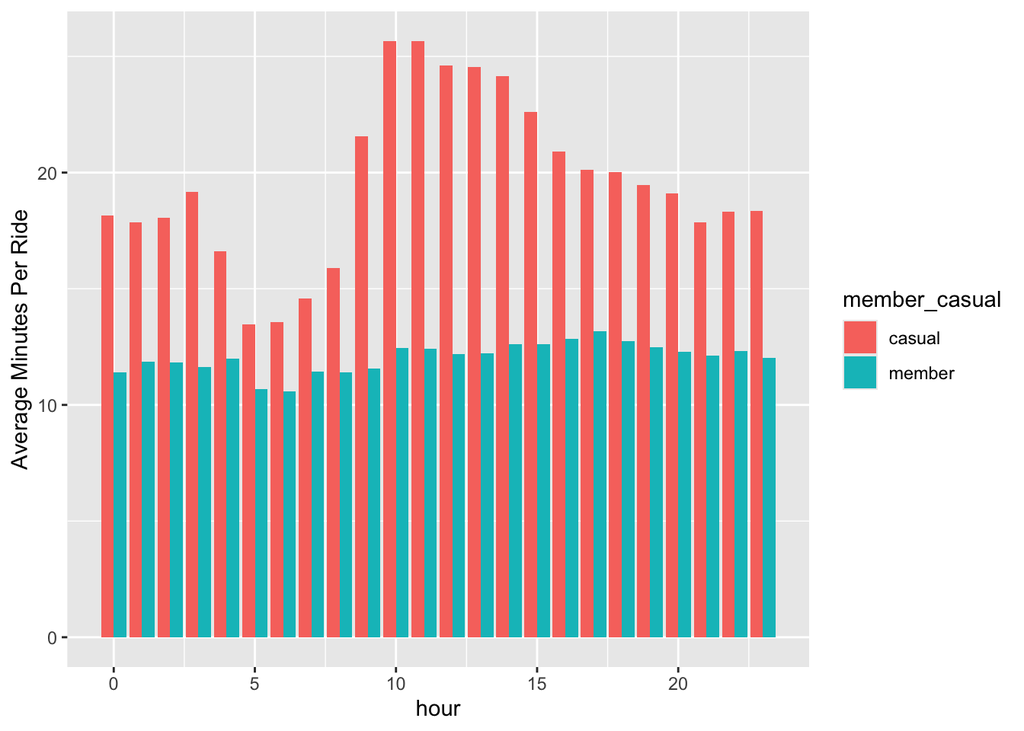

#### Geographical Differences

Casual rides occur in a narrow, vertical band in Northeast Chicago, near Chicago Downtown and Near North Side. According to ChatGPT, these are tourist areas and dense commercial districts. Members are more diffuse in where they ride, spreading out into residential areas.

All this indicates that casual users explore the city, while members go between home and the city, as a commuter or resident would.

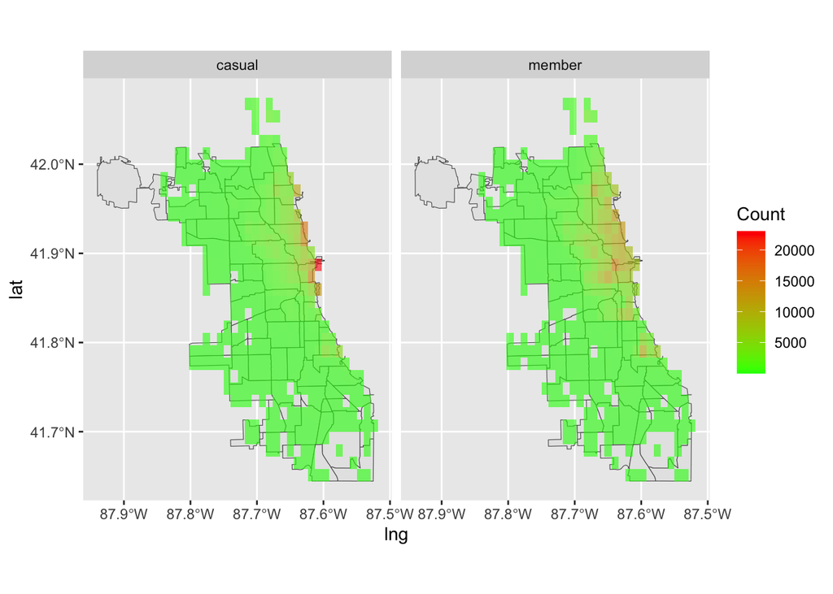

## Takeaways

Members are commuters and people who know where they’re going. They appear to be utilitarian in their use of the bikes. Casual riders generally explore the city.

To target casual riders,

- verify these results with a survey asking casual and member riders why they ride. Check if athleticism is the cause of shorter bike ride times for members.
- Target casual riders who live near downtown and can use Divvy for their commutes.
- Remind users that Divvy can be used for work and not just play